# Session 5: Data Summary And Visualization

Mobina Pourmoshir

2/16/2024

# What is Summary Statistics/Descriptive Statistics?

- Data gathered for any analysis is useful when it is properly represented for easy comprehension and to help in proper decision making.
- After we carry out the data analysis, we delineate its summary so as to understand it in a much better way. This is known as summarizing the data.
- In `R` we can summarize data as follows:
  - Descriptive/Summary Statistics
  - Tabulation
  - Graphical

# Summary Commands in R

- As an analyst, you need to have an overview of the dataset you are dealing with.
- There are a few ways of doing this:
  - `ls()` - used to know the list of named objects that you have.
  - `str()` - gives the structure of an object (dataset).
  - `summary()` - gives a statistical summary of your dataset.

```r
Species <- c("Red maple","Aspen","Hackberry","Lodgepole pine","Swamp white oak","Black cherry","Eastern white pine")
 Girth <- c(8.3, 8.6, 8.8, 10.5, 10.7, 10.8, 11.0)
 Height <- c(70, 65, 63, 72, 81, 83, 66)
 Volume <- c(10.3, 10.3, 10.2, 16.4, 18.8, 19.7, 15.6)
mytrees <- data.frame(Species,Girth,Height,Volume)
mytrees
```

```
##              Species Girth Height Volume
## 1          Red maple   8.3     70   10.3
## 2              Aspen   8.6     65   10.3
## 3          Hackberry   8.8     63   10.2
## 4     Lodgepole pine  10.5     72   16.4
## 5    Swamp white oak  10.7     81   18.8
## 6       Black cherry  10.8     83   19.7
## 7 Eastern white pine  11.0     66   15.6
```

```r
#ls(mytrees)     # listing the named objects
#str(mytrees)    #description of the output
#summary(mytrees)  #statistical summary
```

# Name Commands in R

- Name command and its variants are used to find or add names to rows and columns of data structures.
  - `names()` – It works on matrix or data frame objects.
  - `rownames()` – It works on matrix or data frame objects and is used to give names to rows.
  - `colnames()` – It works on matrix or data frame objects and is used to give names to columns.
  - `dimnames()` – Gets row and column names for matrix or data frame objects, that is, it is used to see dimensions of the data frame.

```r
names(mytrees)
```

```
## [1] "Species" "Girth"   "Height"  "Volume"
```

```r
rownames(mytrees)
```

```
## [1] "1" "2" "3" "4" "5" "6" "7"
```

```r
colnames(mytrees)
```

```
## [1] "Species" "Girth"   "Height"  "Volume"
```

```r
dimnames(mytrees)
```

```
## [[1]]
## [1] "1" "2" "3" "4" "5" "6" "7"
##
## [[2]]
## [1] "Species" "Girth"   "Height"  "Volume"
```

# Summary Commands

- Commands that produce a single value as output.
  - `max(x, na.rm = FALSE)` – It shows the maximum value.
  - `min(x, na.rm = FALSE)` – Shows minimum value in a vector.
  - `length(x)` – Gives length of the vector and includes na values.
  - `sum(x, na.rm = FALSE)` – Shows the sum of the vector elements.
  - `mean(x, na.rm = FALSE)` – We obtain an arithmetic mean with this.
  - `median( x, na.rm = FALSE)` – Shows the median value of the vector.
  - `sd(x, na.rm = FALSE)` – Shows the standard deviation.
  - `var(x, na.rm = FALSE)` – Shows the variance.
  - `mad(x, na.rm = FALSE)` – Shows the median absolute deviation.
    - By default, NA values are not removed. Use the `na.rm = TRUE` instruction to remove NA’s for accurate results.
- Some commands that produce multiple outputs.
  - `log(dataset)` – Shows log value for each element.
  - `summary(dataset)` – We have seen how it shows a summary of dataset like maximum value, minimum value, mean, etc.
  - `quantile()` – Shows the quantiles by default—the 0%, 25%, 50%, 75%, and 100% quantiles.
    - If the data contains NA items, you must remove them using the `na.rm = TRUE` instruction, otherwise, you get an error message.

```r
Height
```

```
## [1] 70 65 63 72 81 83 66
```

```r
max(Height)
```

```
## [1] 83
```

```r
min(Height)
```

```
## [1] 63
```

```r
length(Height)
```

```
## [1] 7
```

```r
sum(Height)
```

```
## [1] 500
```

```r
mean(Height)
```

```
## [1] 71.42857
```

```r
median(Height)
```

```
## [1] 70
```

```r
sd(Height)
```

```
## [1] 7.84978
```

```r
var(Height)
```

```
## [1] 61.61905
```

```r
mad(Height)
```

```
## [1] 7.413
```

```r
log(Height)
```

```
## [1] 4.248495 4.174387 4.143135 4.276666 4.394449 4.418841 4.189655
```

```r
quantile(Height)
```

```
##   0%  25%  50%  75% 100%
## 63.0 65.5 70.0 76.5 83.0
```

# Simple Cumulative Commands in R

- These commands need only the name of the object.
- Cumulative commands produce an accurate result when applied to a vector of numeric data
- if applied on character data, they give error populated as a list of NA items.
- If the numeric vector contains NA, the cumulative command will work till first NA and thereafter give all result as NA.
  - `Cumsum(x)` – The cumulative sum of a vector.
  - `Cummax(x)` – The cumulative maximum value.
  - `Cumin(x)` – The cumulative minimum value.
  - `Cumprod(x)` – The cumulative product.

```r
mytrees$Species
```

```
## [1] "Red maple"          "Aspen"              "Hackberry"
## [4] "Lodgepole pine"     "Swamp white oak"    "Black cherry"
## [7] "Eastern white pine"
```

```r
mytrees$Girth
```

```
## [1]  8.3  8.6  8.8 10.5 10.7 10.8 11.0
```

```r
cumsum(mytrees$Species)
```

```
## [1] NA NA NA NA NA NA NA
```

```r
cummax(mytrees$Girth)
```

```
## [1]  8.3  8.6  8.8 10.5 10.7 10.8 11.0
```

```r
cummin(mytrees$Girth)
```

```
## [1] 8.3 8.3 8.3 8.3 8.3 8.3 8.3
```

```r
cumprod(mytrees$Girth)
```

```
## [1]       8.300      71.380     628.144    6595.512   70571.978  762177.367
## [7] 8383951.034
```

# Descriptive Statistics in R for Data Frames

- `Max(frame)` – Returns the largest value in the entire data frame (with all numeric variables).
- `Min(frame)` – Returns the smallest value in the entire data frame.
- `Sum(frame)` – Returns the sum of the entire data frame.
- `Fivenum(frame)` – Returns the Tukey summary values for the entire data frame.
- `Length(frame)` - Returns the number of columns in the data frame.
- `Summary(frame)` – Returns the summary for each column.
- **Row Summary Commands** – Applied to work with row data.
  - `rowmeans()`
  - `rowsums()`
- **Column Summary Commands** – Also, applied to work with row data.
  - `colmeans()`
  - `colsums()`

```r
mytrees1 <- data.frame(Girth, Height, Volume)

max(mytrees1)
```

```
## [1] 83
```

```r
min(mytrees1)
```

```
## [1] 8.3
```

```r
sum(mytrees1)
```

```
## [1] 670
```

```r
fivenum(mytrees1$Girth)
```

```
## [1]  8.30  8.70 10.50 10.75 11.00
```

```r
length(mytrees1)
```

```
## [1] 3
```

# The apply() Command in R for Summaries

- `Colmeans()` and `rowsums()` commands are quick alternative to a more general command `apply()`.
- The `apply()` command enables applying a function to the rows or columns of a matrix or data frame.
- The general form of the command is: `apply(X, MARGIN, FUN, ...)`
  - `x` specifies the matrix or data frame.
  - `MARGIN` command uses either 1 or 2, where 1 is for rows and 2 is for columns.
  - You replace the FUN part with your command (the function you want to apply).
  - All of the columns or rows should be numeric.

```r
str(mytrees1)
```

```
## 'data.frame':    7 obs. of  3 variables:
##  $ Girth : num  8.3 8.6 8.8 10.5 10.7 10.8 11
##  $ Height: num  70 65 63 72 81 83 66
##  $ Volume: num  10.3 10.3 10.2 16.4 18.8 19.7 15.6
```

```r
max(mytrees1)
```

```
## [1] 83
```

```r
min(mytrees1)
```

```
## [1] 8.3
```

```r
sum(mytrees1)
```

```
## [1] 670
```

```r
fivenum(mytrees1$Girth)
```

```
## [1]  8.30  8.70 10.50 10.75 11.00
```

```r
length(mytrees1)
```

```
## [1] 3
```

```r
colMeans(mytrees1)
```

```
##     Girth    Height    Volume
##  9.814286 71.428571 14.471429
```

```r
apply(mytrees1, 2, mean)
```

```
##     Girth    Height    Volume
##  9.814286 71.428571 14.471429
```

```r
colSums(mytrees1)
```

```
##  Girth Height Volume
##   68.7  500.0  101.3
```

```r
apply(mytrees1, 2, sum)
```

```
##  Girth Height Volume
##   68.7  500.0  101.3
```

# Graphical Summaries

- Much of the statistical analysis is based on numerical techniques, and these techniques are based on assumptions about the data being used.
- Graphical data analysis with R, is one way to determine if data satisfy the assumptions.
- Graphs are useful for non-numerical data.When numerical measures are difficult or impossible to compute, graphs play an important role.
- Statistical computing is done with the aim to produce high-quality graphics.

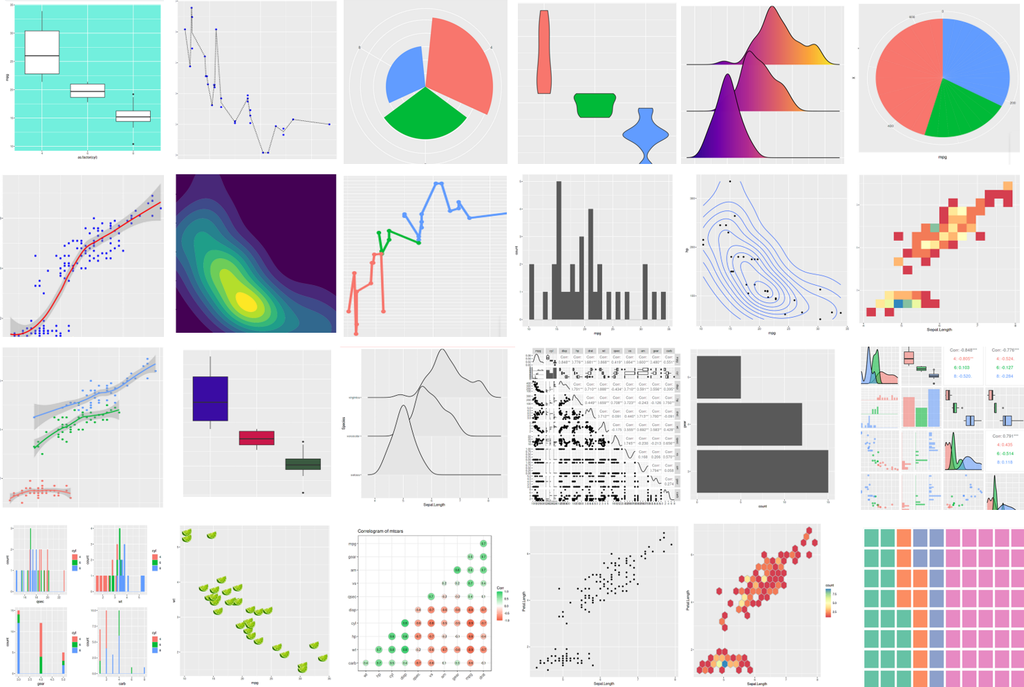

# Various types of plots

- Plots with Single Variable – You can plot a graph for a single variable.
  - Histogram, `hist(y)`
  - Pie chart, `pie(y)`
  - Time series, `plot.ts(y)`

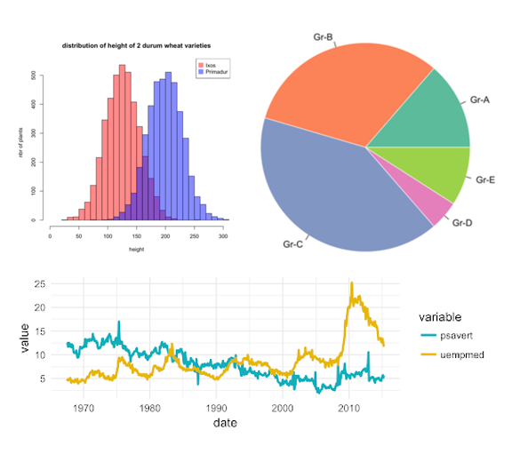

- Plots with Two Variables – You can plot a graph with two variables.
  - Scatterplot of `y` against `x`, `plot(x,y)`.
  - Box-and-whisker plot of y at each factor level. `plot(factor,y)`
  - Barplot, `barplot(y)`

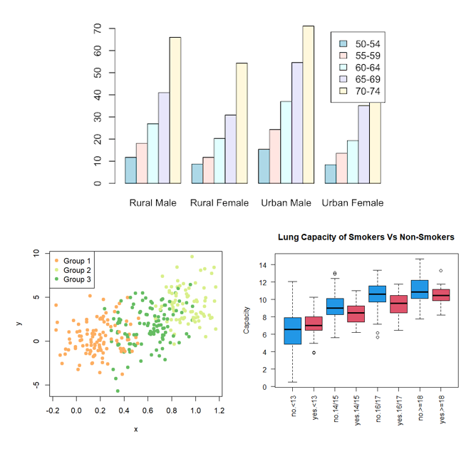

- Plots with Multiple Variables – You can plot a graph with multiple variables.
  - The Pairs Function: (`pairs(y)`) is a matrix of scatterplots of every variable against every other.
  - The Coplot Function: `coplot(x,y|z)` – For conditioning plots where y is plotted against x for different values of z.

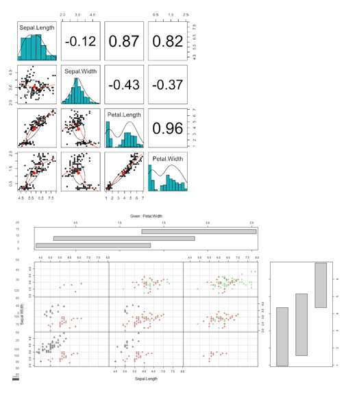

- Special Plots – R has low and high-level graphics facilities.
  - Design plots : `plot.design()` Plot univariate effects of one or more factors, typically for a designed experiment as analyzed by aov().
  - Bubble plots

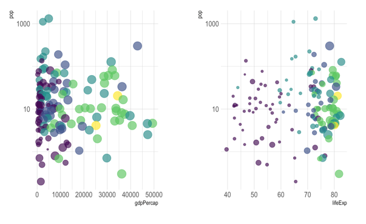

# Plots with Single Variable

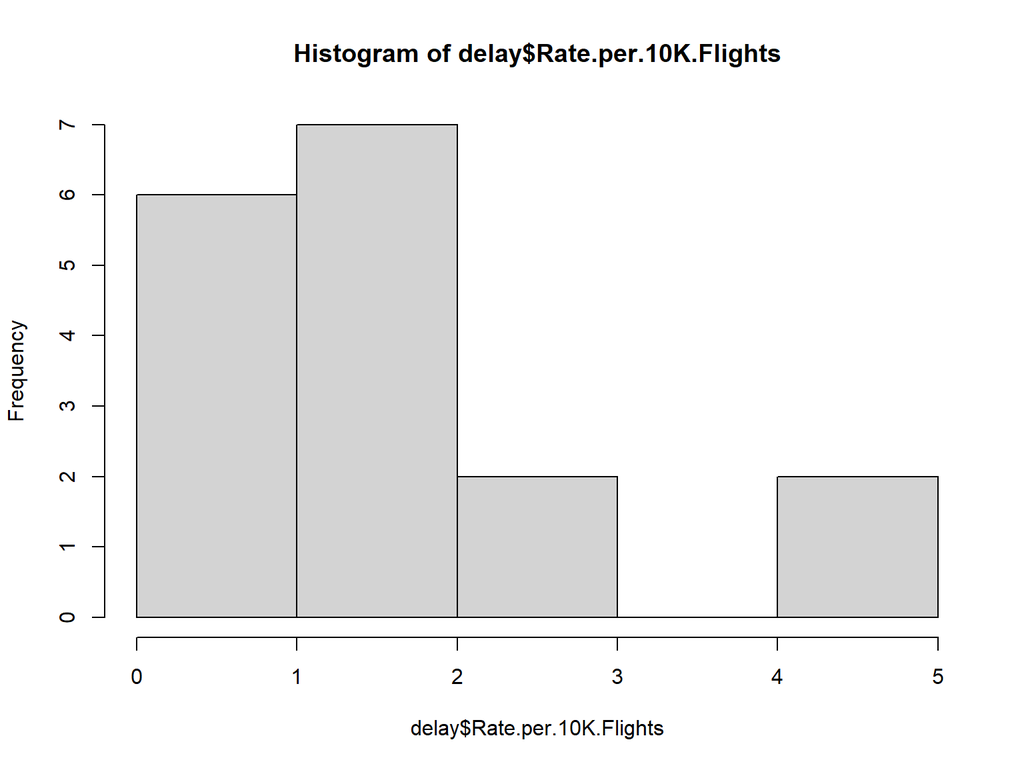

```r
delay <- read.csv("C:/Users/PC/Desktop/Spring 2024/MATH 4730 Introduction to R/data_sets/flight.delay.csv", header = TRUE) # load the data


hist(delay$Rate.per.10K.Flights)
```

```r
str(chickwts)
```

```
## 'data.frame':    71 obs. of  2 variables:
##  $ weight: num  179 160 136 227 217 168 108 124 143 140 ...
##  $ feed  : Factor w/ 6 levels "casein","horsebean",..: 2 2 2 2 2 2 2 2 2 2 ...
```

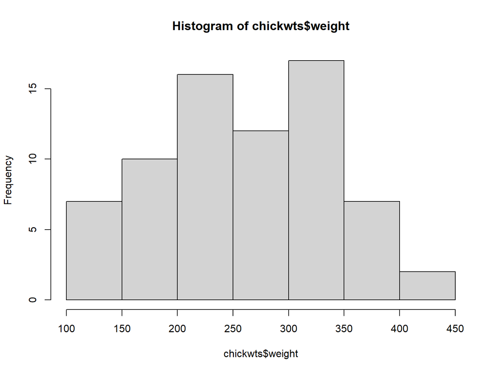

```r
hist(chickwts$weight) # histogram of weight
```

```r
stem(chickwts$weight) # stemand leaf plot of weight
```

```
##
##   The decimal point is 2 digit(s) to the right of the |
##
##   1 | 124444
##   1 | 5566777889
##   2 | 00112223333444
##   2 | 5556666667778
##   3 | 0001222222333334444
##   3 | 5678899
##   4 | 02
```

# Plots with Two Variables

```r
str(delay)
```

```
## 'data.frame':    17 obs. of  3 variables:
##  $ Airline             : chr  "ExpressJet" "Continental" "Delta" "Comair" ...
##  $ Delays              : int  93 72 81 29 44 46 18 48 24 17 ...
##  $ Rate.per.10K.Flights: num  4.9 4.1 2.8 2.7 1.6 1.6 1.4 1.3 1.2 1.1 ...
```

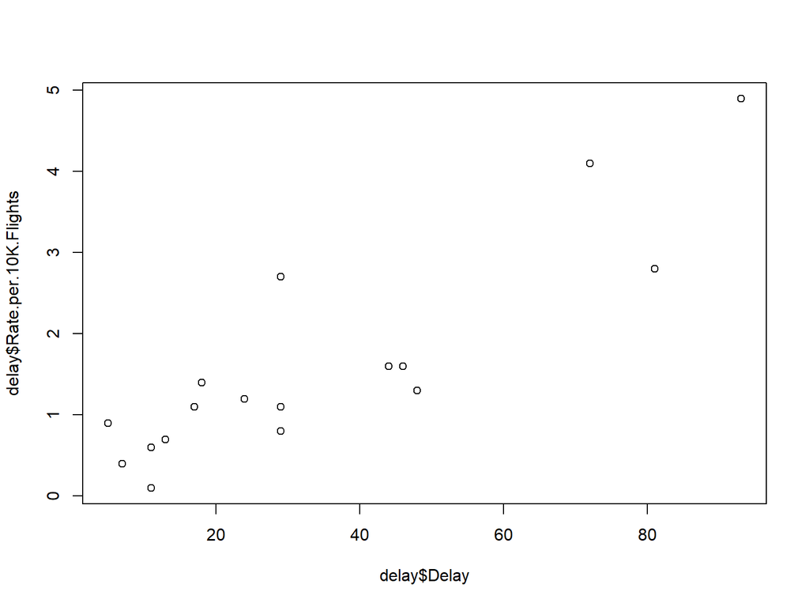

```r
plot(delay$Delay, delay$Rate.per.10K.Flights) # scatter plot Delay against Rate per 10K flights
```

```r
str(chickwts)
```

```
## 'data.frame':    71 obs. of  2 variables:
##  $ weight: num  179 160 136 227 217 168 108 124 143 140 ...
##  $ feed  : Factor w/ 6 levels "casein","horsebean",..: 2 2 2 2 2 2 2 2 2 2 ...
```

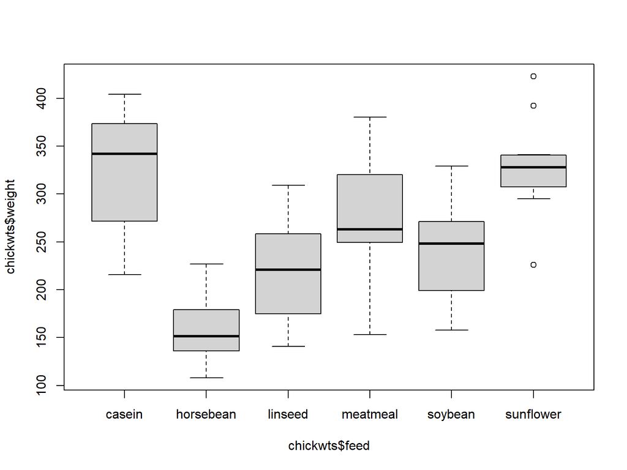

```r
boxplot(chickwts$weight ~ chickwts$feed) # boxplot of weight factored on feed
```

```r
str(chickwts)
```

```
## 'data.frame':    71 obs. of  2 variables:
##  $ weight: num  179 160 136 227 217 168 108 124 143 140 ...
##  $ feed  : Factor w/ 6 levels "casein","horsebean",..: 2 2 2 2 2 2 2 2 2 2 ...
```

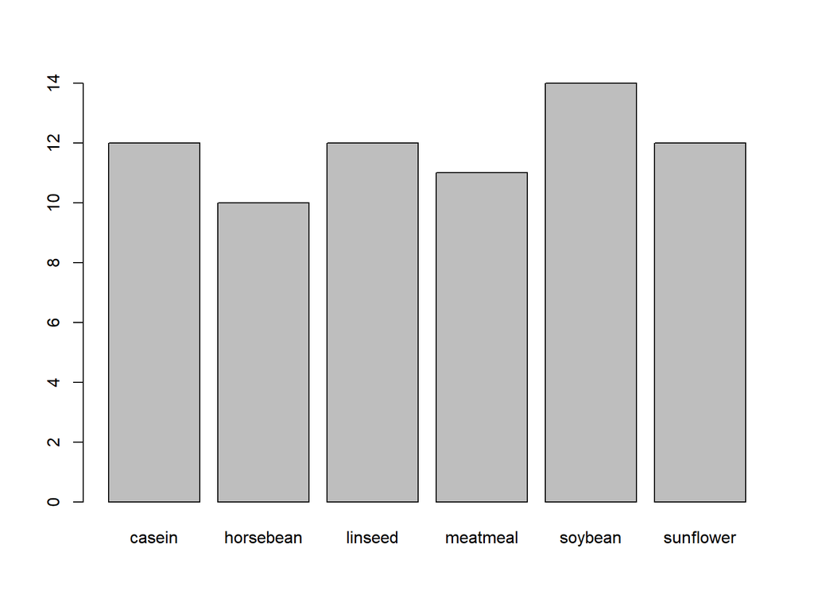

```r
barplot(table(chickwts$feed))  # bargragh of feed
```

# Plots with Multiple Variables

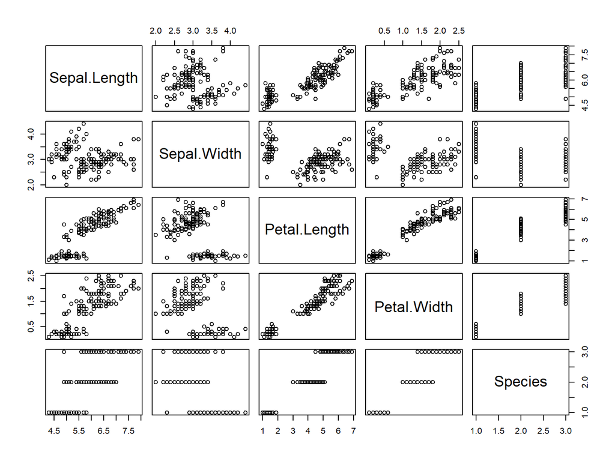

```r
pairs(iris)
```

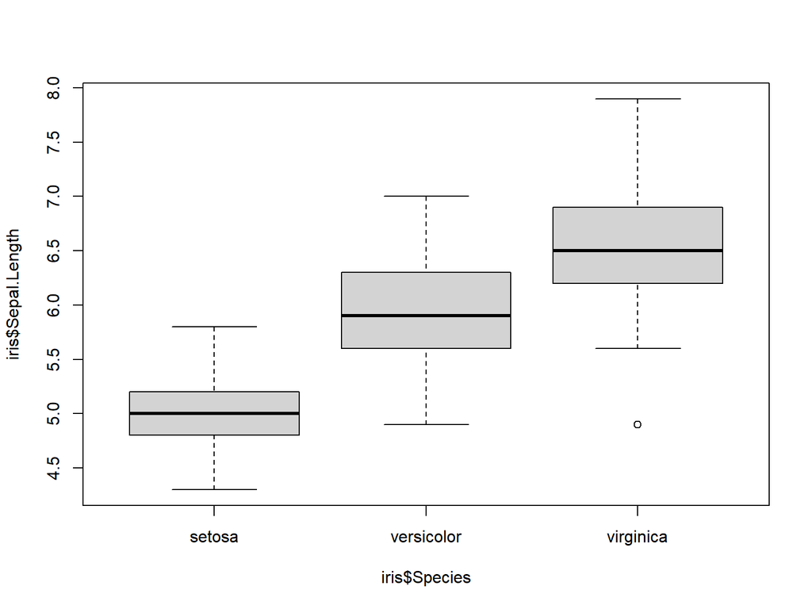

```r
boxplot(iris$Sepal.Length ~ iris$Species)
```

```r
mlb16.data <- read.csv("C:/Users/PC/Desktop/Spring 2024/MATH 4730 Introduction to R/data_sets/mlb16.csv",header=TRUE)
```

```r
str(mlb16.data) # check structure
```

```
## 'data.frame':    30 obs. of  14 variables:
##  $ Tm    : chr  "ARI" "ATL" "BAL" "BOS" ...
##  $ Lg    : chr  "NL" "NL" "AL" "AL" ...
##  $ BatAge: num  26.7 28.9 28.4 28.5 27.4 28.3 27.8 28.9 27.8 29.8 ...
##  $ RPG   : num  4.64 4.03 4.59 5.42 4.99 4.23 4.42 4.83 5.22 4.66 ...
##  $ G     : int  162 161 162 162 162 162 162 161 162 161 ...
##  $ AB    : int  5665 5514 5524 5670 5503 5550 5487 5484 5614 5526 ...
##  $ R     : int  752 649 744 878 808 686 716 777 845 750 ...
##  $ H     : int  1479 1404 1413 1598 1409 1428 1403 1435 1544 1476 ...
##  $ HR    : int  190 122 253 208 199 168 164 185 204 211 ...
##  $ RBI   : int  709 615 710 836 767 656 678 733 805 719 ...
##  $ SO    : int  1427 1240 1324 1160 1339 1285 1284 1246 1330 1303 ...
##  $ BA    : num  0.261 0.255 0.256 0.282 0.256 0.257 0.256 0.262 0.275 0.267 ...
##  $ SH    : int  43 64 17 8 42 29 58 31 54 17 ...
##  $ SF    : int  38 52 36 40 37 44 44 60 34 38 ...
```

```r
head(mlb16.data)  # show first six rows
```

```
##    Tm Lg BatAge  RPG   G   AB   R    H  HR RBI   SO    BA SH SF
## 1 ARI NL   26.7 4.64 162 5665 752 1479 190 709 1427 0.261 43 38
## 2 ATL NL   28.9 4.03 161 5514 649 1404 122 615 1240 0.255 64 52
## 3 BAL AL   28.4 4.59 162 5524 744 1413 253 710 1324 0.256 17 36
## 4 BOS AL   28.5 5.42 162 5670 878 1598 208 836 1160 0.282  8 40
## 5 CHC NL   27.4 4.99 162 5503 808 1409 199 767 1339 0.256 42 37
## 6 CHW AL   28.3 4.23 162 5550 686 1428 168 656 1285 0.257 29 44
```

```r
tapply(mlb16.data$RPG, mlb16.data$Lg, mean)
```

```
##       AL       NL
## 4.519333 4.437333
```

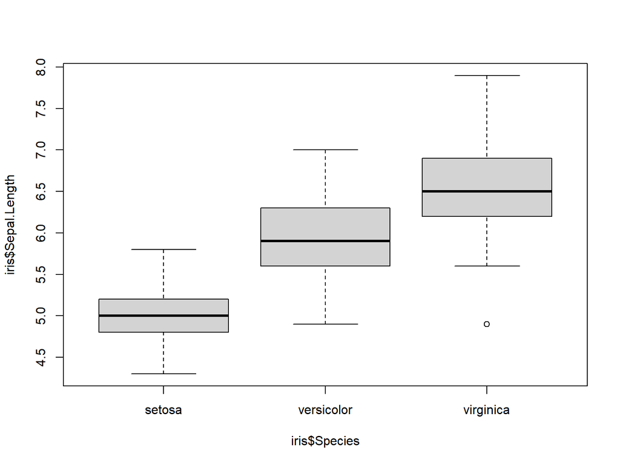

```r
boxplot(iris$Sepal.Length ~ iris$Species)
```

# Ranking Plots in ggplot2

- We can make fancier plots using ggplot2.

##### Bar plot

```r
df <- data.frame(
  Category = c("A", "B", "C", "D", "E"),
  Value = c(10, 15, 8, 12, 20)
)
print(df)
```

```
##   Category Value
## 1        A    10
## 2        B    15
## 3        C     8
## 4        D    12
## 5        E    20
```

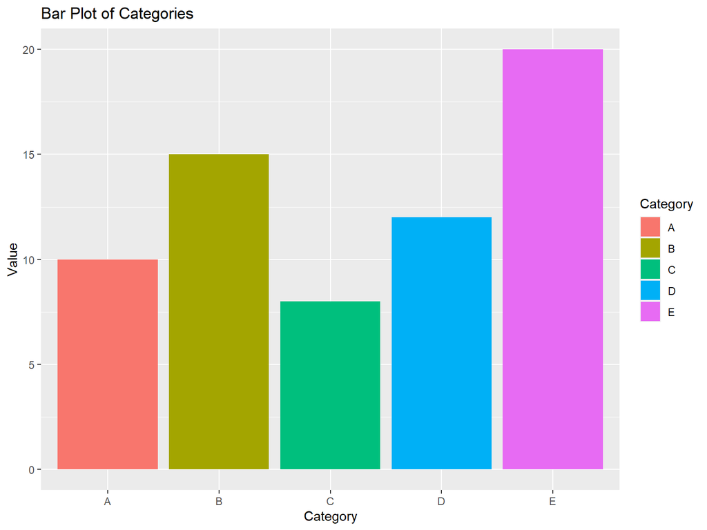

```r
library(ggplot2)

ggplot(df, aes(x = Category, y = Value, fill = Category)) +
  geom_bar(stat = "identity") +
  labs(title = "Bar Plot of Categories",
       x = "Category",
       y = "Value")
```

##### Pie Plot

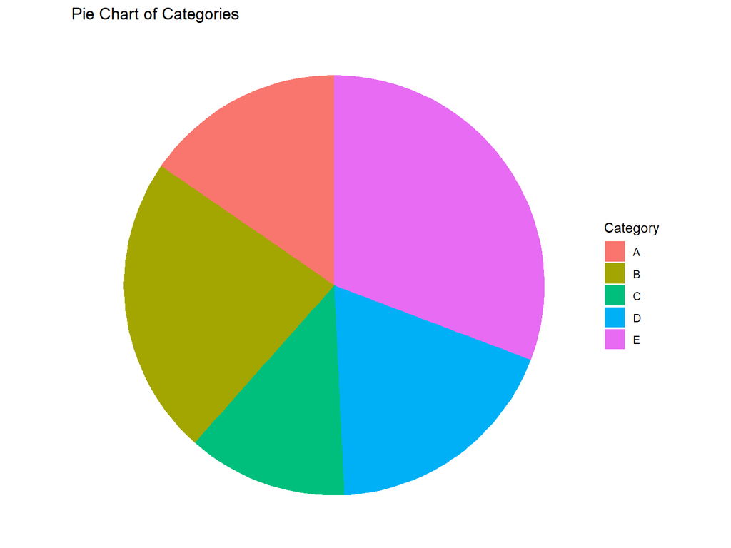

```r
ggplot(df, aes(x = "", y = Value, fill = Category)) +
  geom_bar(stat = "identity", width = 1) +
  coord_polar("y", start = 0) +
  labs(title = "Pie Chart of Categories",
       fill = "Category") +
  theme_void() +
  theme(legend.position = "right")
```

# Showing density and distributions in ggplot2

##### Histograms

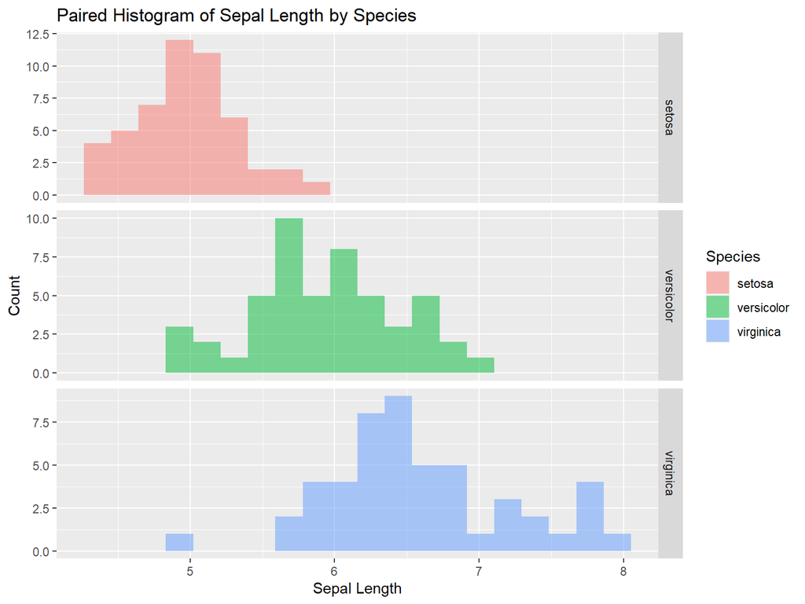

```r
library(ggplot2)

ggplot(iris, aes(x = Sepal.Length, fill = Species)) +
  geom_histogram(position = "identity", alpha = 0.5, bins = 20) +
  facet_grid(Species ~ ., scales = "free_y") +
  labs(title = "Paired Histogram of Sepal Length by Species",
       x = "Sepal Length",
       y = "Count")
```

##### Curves

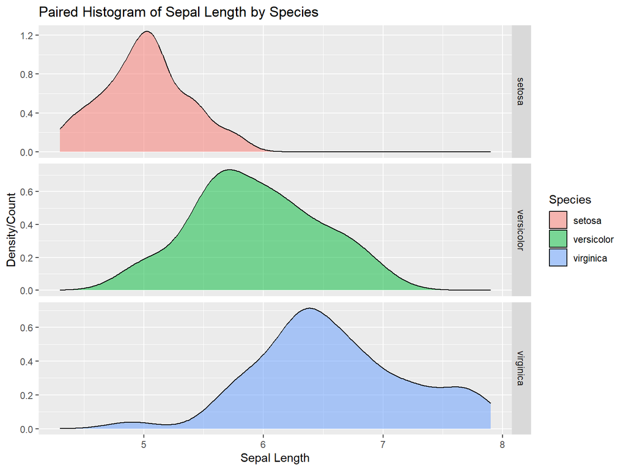

```r
library(ggplot2)

ggplot(iris, aes(x = Sepal.Length, fill = Species)) +
  geom_density(alpha = 0.5, color = "black") +
  facet_grid(Species ~ ., scales = "free_y") +
  labs(title = "Paired Histogram of Sepal Length by Species",
       x = "Sepal Length",
       y = "Density/Count")
```

##### Box Plots

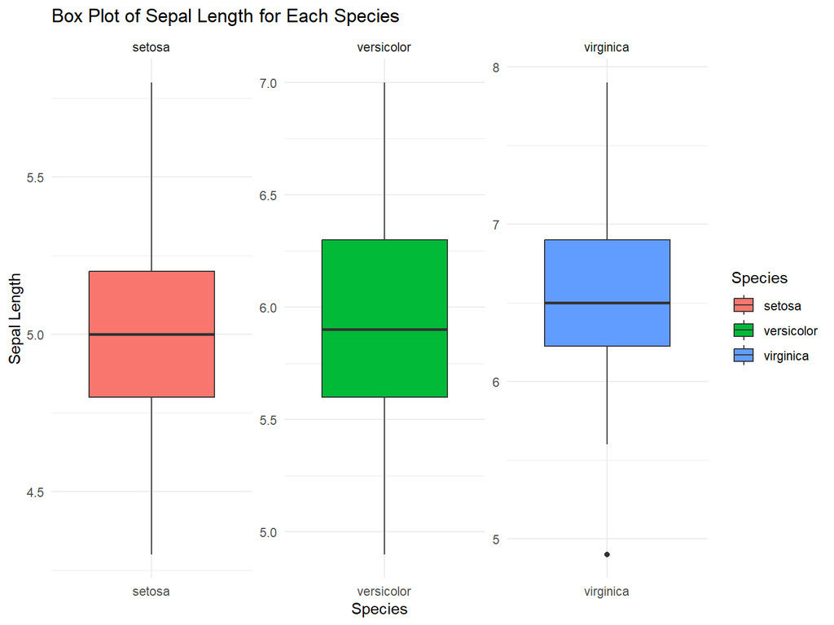

```r
ggplot(iris, aes(x = Species, y = Sepal.Length, fill = Species)) +
  geom_boxplot() +
  facet_wrap(~Species, scales = "free") +
  labs(title = "Box Plot of Sepal Length for Each Species",
       x = "Species",
       y = "Sepal Length",
       fill = "Species") +
  theme_minimal()
```

# Other Plots in ggplot2

##### Scatter plot

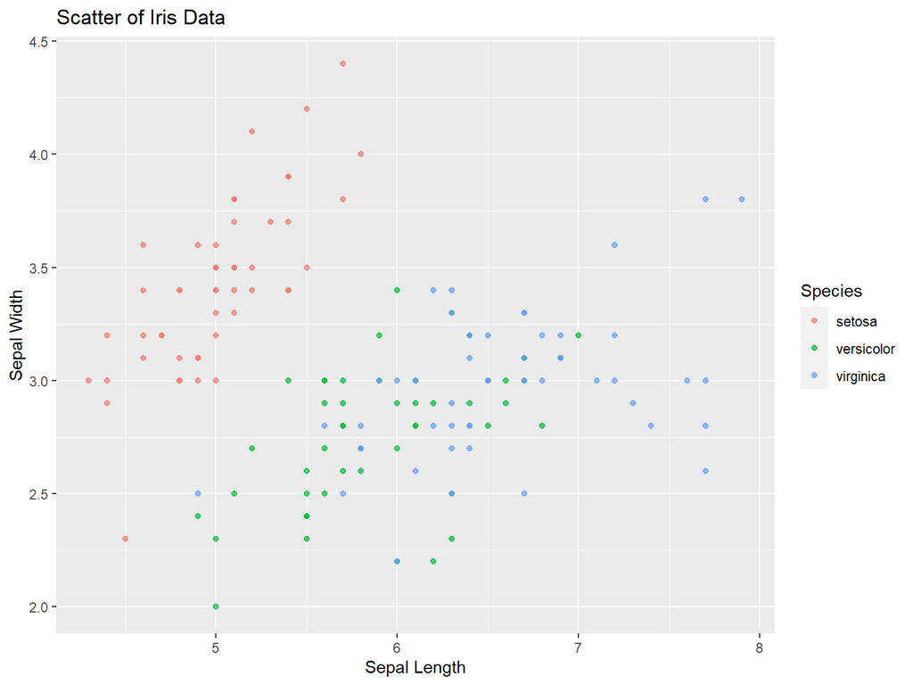

```r
ggplot(iris, aes(x = Sepal.Length, y = Sepal.Width, color = Species)) +
  geom_point(alpha = 0.7) +
  labs(title = "Scatter of Iris Data",
       x = "Sepal Length",
       y = "Sepal Width",
       size = "Petal Length",
       color = "Species")
```

##### Bubble Chart

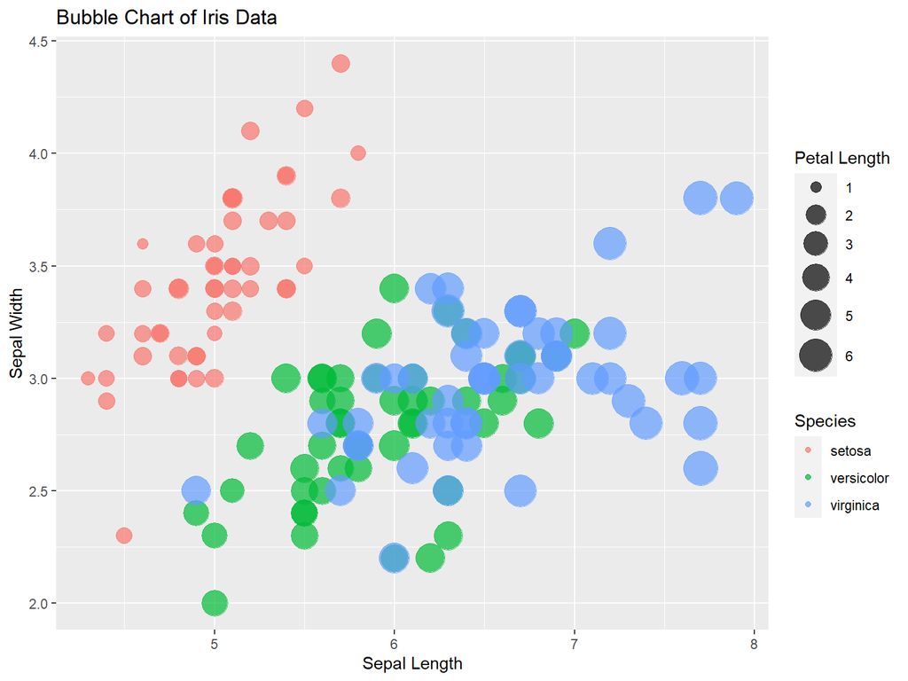

```r
library(ggplot2)


ggplot(iris, aes(x = Sepal.Length, y = Sepal.Width, size = Petal.Length, color = Species)) +
  geom_point(alpha = 0.7) +
  scale_size_continuous(range = c(3, 10)) +
  labs(title = "Bubble Chart of Iris Data",
       x = "Sepal Length",
       y = "Sepal Width",
       size = "Petal Length",
       color = "Species")
```

##### Line Charts

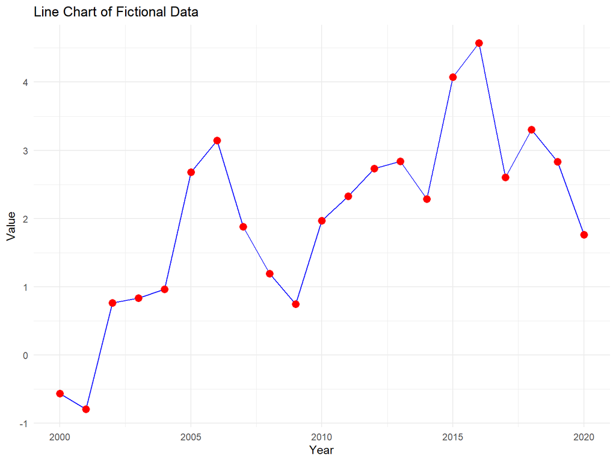

```r
set.seed(123)
data <- data.frame(
  Year = 2000:2020,
  Value = cumsum(rnorm(21))
)

# Line chart
ggplot(data, aes(x = Year, y = Value)) +
  geom_line(color = "blue") +
  geom_point(color = "red", size = 3) +
  labs(title = "Line Chart of Fictional Data",
       x = "Year",
       y = "Value") +
  theme_minimal()
```

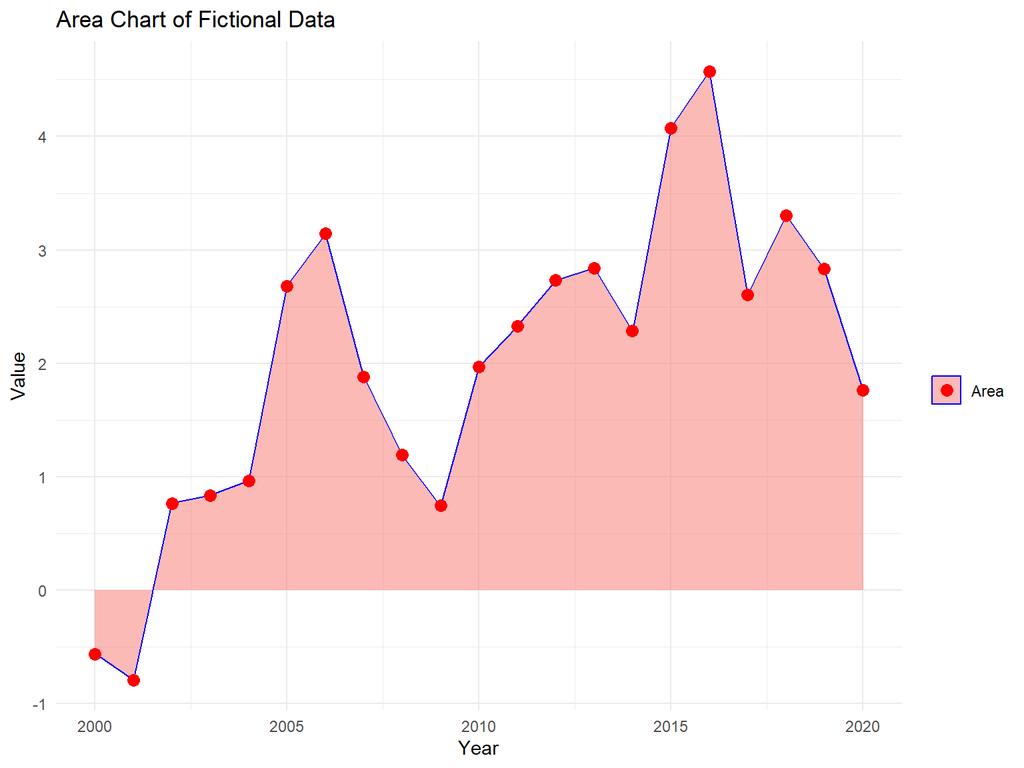

```r
# Area chart
ggplot(data, aes(x = Year, y = Value, fill = "Area")) +
  geom_area(color = "blue", alpha = 0.5) +
  geom_point(color = "red", size = 3) +
  labs(title = "Area Chart of Fictional Data",
       x = "Year",
       y = "Value",
       fill = "") +
  theme_minimal()
```

##### Maps

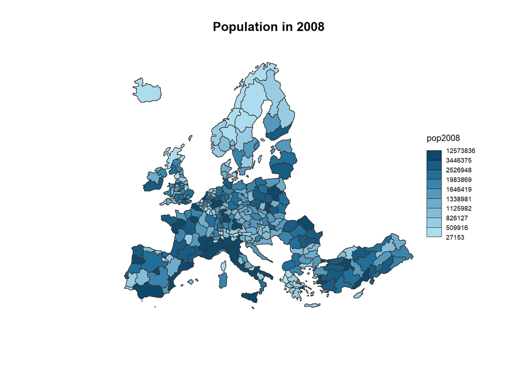

```r
library(cartography)
# Load data
data(nuts2006)

# Build a choropleth
choroLayer(spdf = nuts2.spdf, df = nuts2.df, var = "pop2008" ,
           legend.pos = "right")
title("Population in 2008")
```